# Census employment data QA

Mike Spencer

3 July 2018

## Introduction

### Purpose

This document is part of a project evaluating the importance of hill farming in Scottish communities. It compares census data at output area level (as downloaded), to aggregations at agricultural parish level. The aggregated parishes are then compared to civic parishes, which are broadly similar in name and boundary to the agricultural parishes.

## Absolute values for agricultural parishes

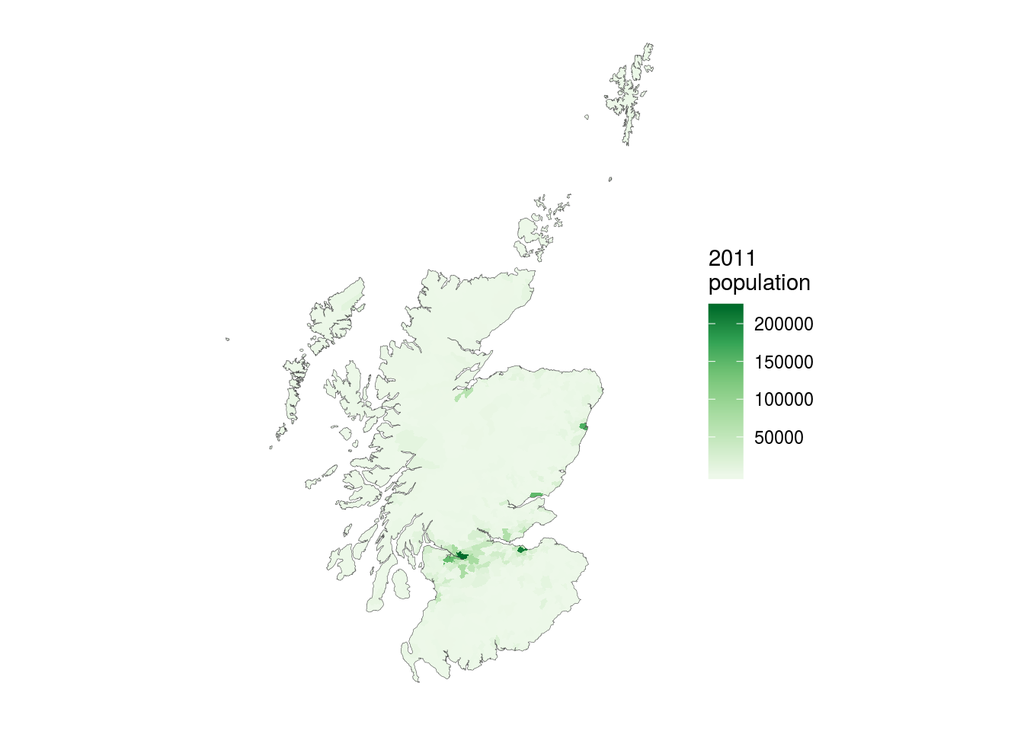

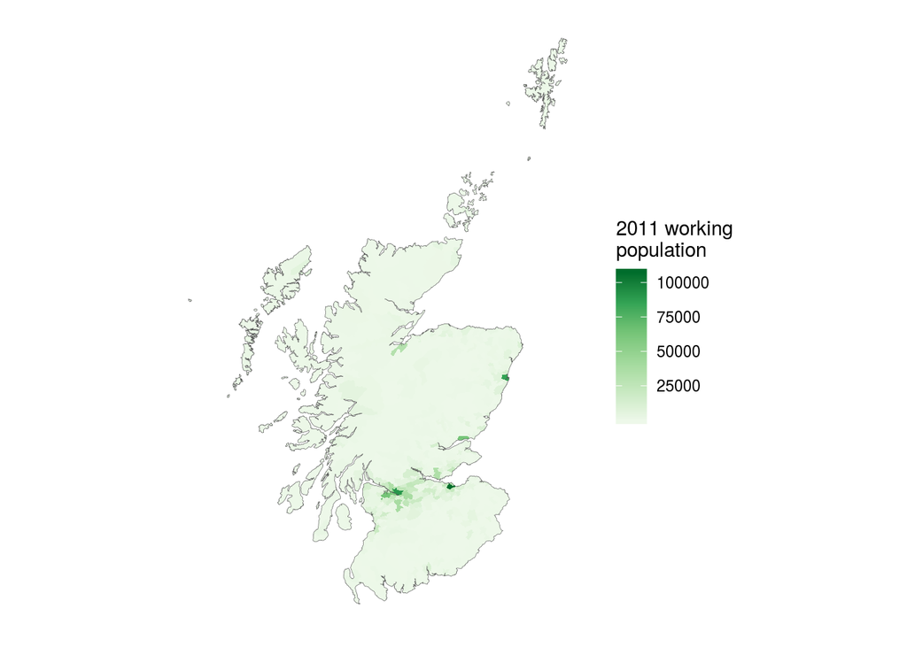

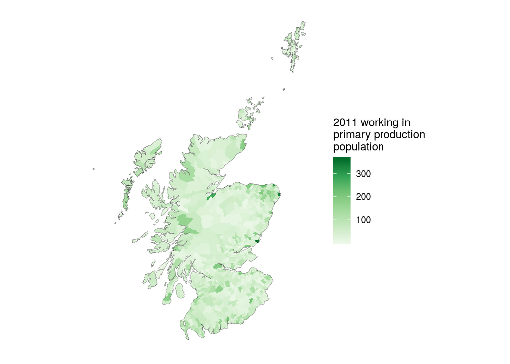

## Proportions for agricultural parishes

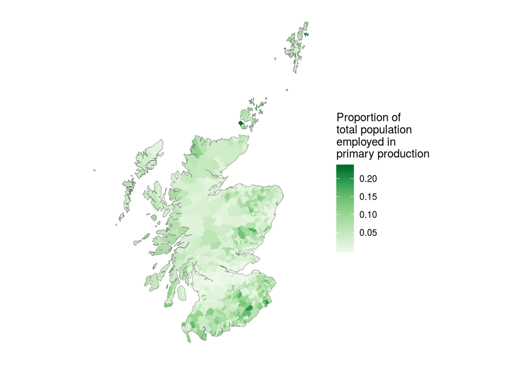

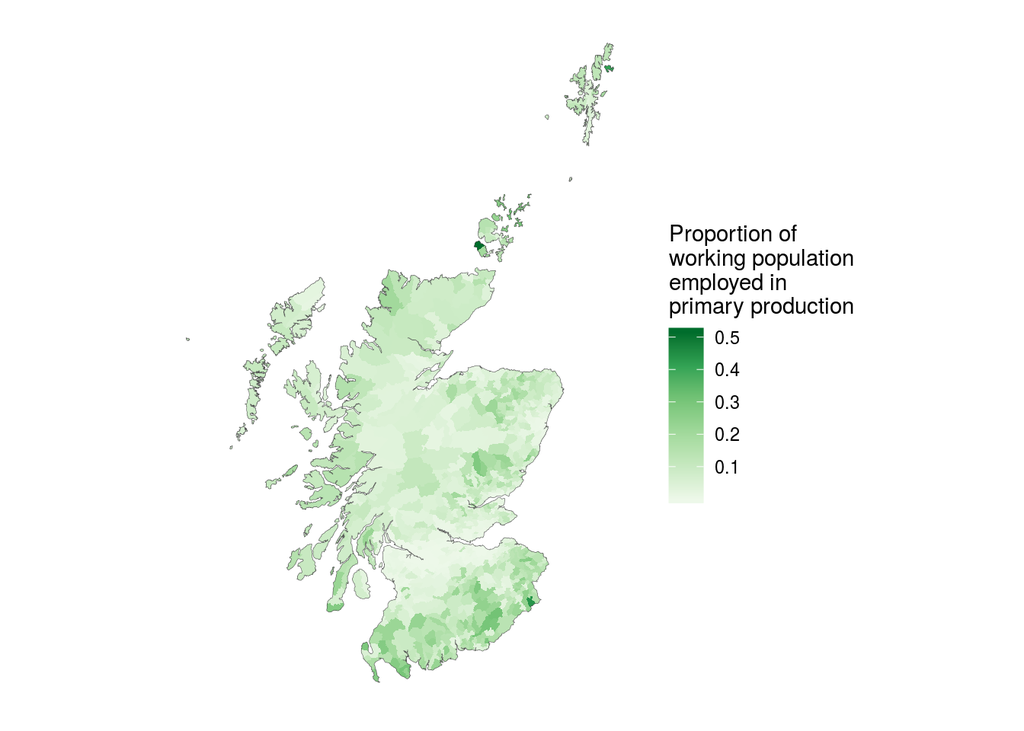

## Checks

### Aggregated to agricultural parishes

- Total people in 2011 = 5293375
- Total working population in 2011 = 2515940
- Ag/for/fish working population in 2011 = 41875
- Proportion in land/primary of total population in 2011 = 0.791%
- Proportion in land/primary of working population in 2011 = 1.66%
- Total people in 2001 = 5055821
- Total working population in 2001 = 2258453
- Ag/for/fish working population in 2001 = 54982
- Proportion in land/primary of total population in 2001 = 1.09%
- Proportion in land/primary of working population in 2001 = 2.43%

### Using census output areas

These values are the benchmark, as they are unaltered from the downloaded versions.

- Total people in 2011 = 5295403
- Total working population in 2011 = 2516895
- Ag/for/fish working population in 2011 = 41902
- Proportion in land/primary of total population in 2011 = 0.791%
- Proportion in land/primary of working population in 2011 = 1.66%
- Total people in 2001 = 5062011
- Total working population in 2001 = 2261281
- Ag/for/fish working population in 2001 = 55145
- Proportion in land/primary of total population in 2001 = 1.09%
- Proportion in land/primary of working population in 2001 = 2.44%

## Maps of census output areas

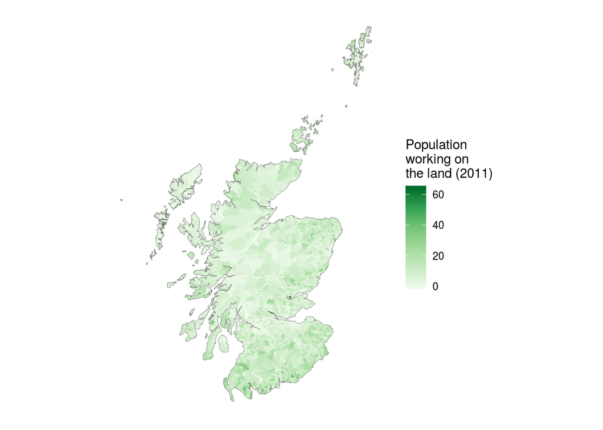

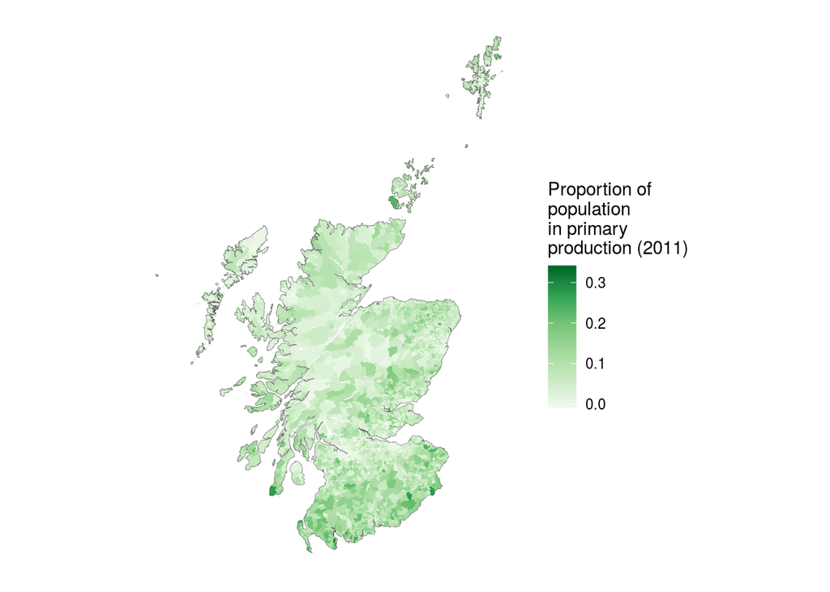

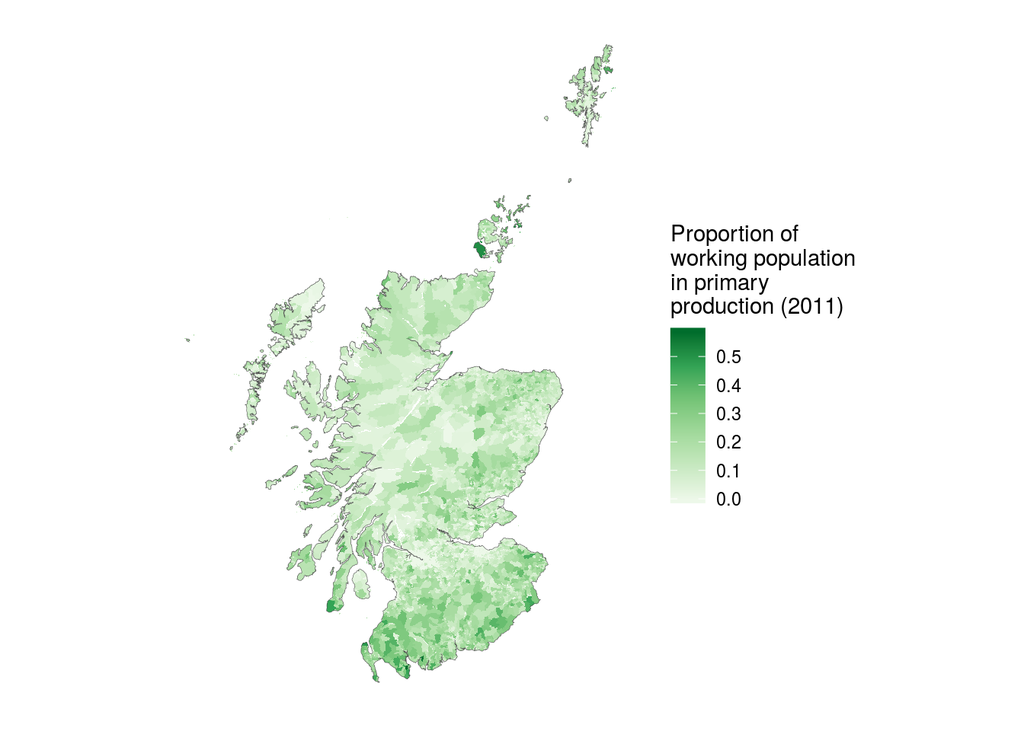

## Compared to historic parishes

Used here are employment figures.

### 2001 and 2011 census sic match

Not all census sic codes match, this is how they have been joined:

- A_agri=`Percentage of people aged 16 to 74 working in: Agriculture, hunting and forestry` + `Percentage of people aged 16 to 74 working in: Fishing`,
- B_mining=`Percentage of people aged 16 to 74 working in: Mining and quarrying`,
- C_manufacture=`Percentage of people aged 16 to 74 working in: Manufacturing`,
- F_construction=`Percentage of people aged 16 to 74 working in: Construction`,
- G_retail=`Percentage of people aged 16 to 74 working in: Wholesale and retail trade, repairs`,
- I_accommo=`Percentage of people aged 16 to 74 working in: Hotels and restaurants`,
- K_finance=`Percentage of people aged 16 to 74 working as: Financial intermediaries`,
- L_estate=`Percentage of people aged 16 to 74 working in: Real estate, renting and business activities`,
- O_public=`Percentage of people aged 16 to 74 working in: Public administration and defence, social security`,
- P_edu=`Percentage of people aged 16 to 74 working in: Education`,
- Q_health=`Percentage of people aged 16 to 74 working in: Health and social work`,
- other=`Percentage of people aged 16 to 74 working in: Other`)

### Civil parish change

How has employment changed in civil parishes between the 2001 and 2011 census?

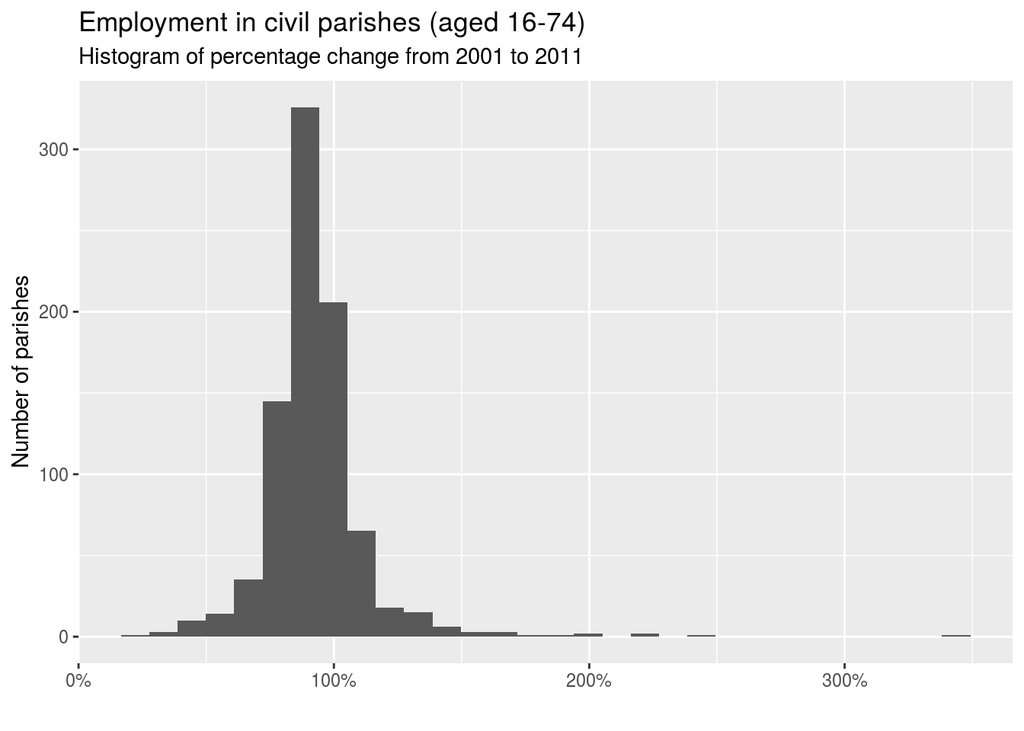

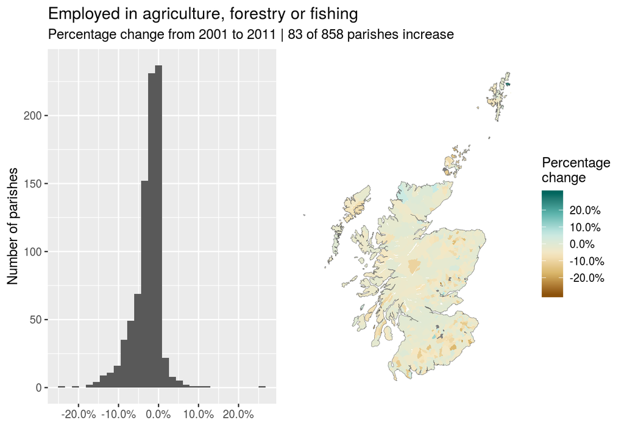

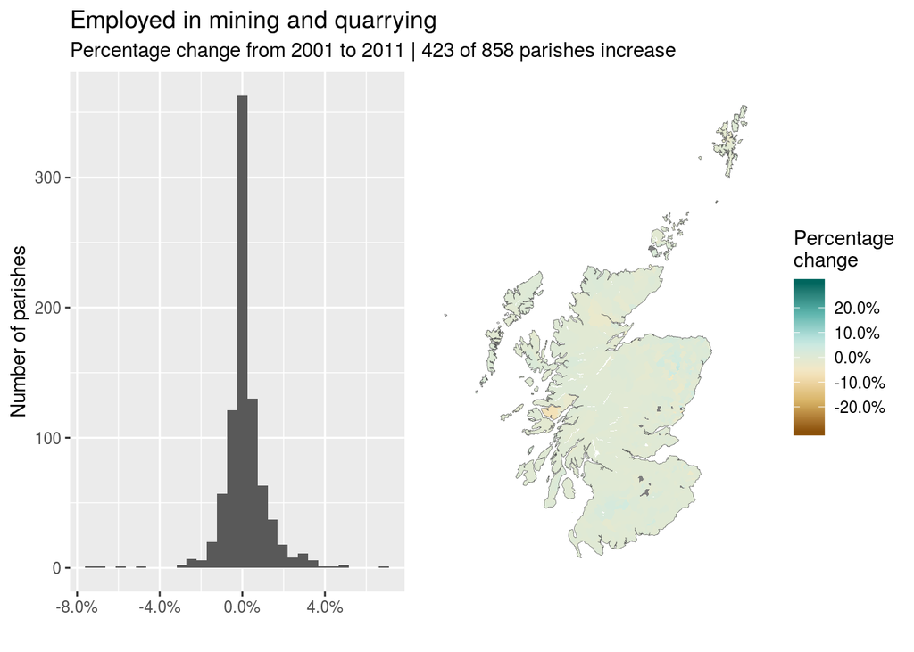

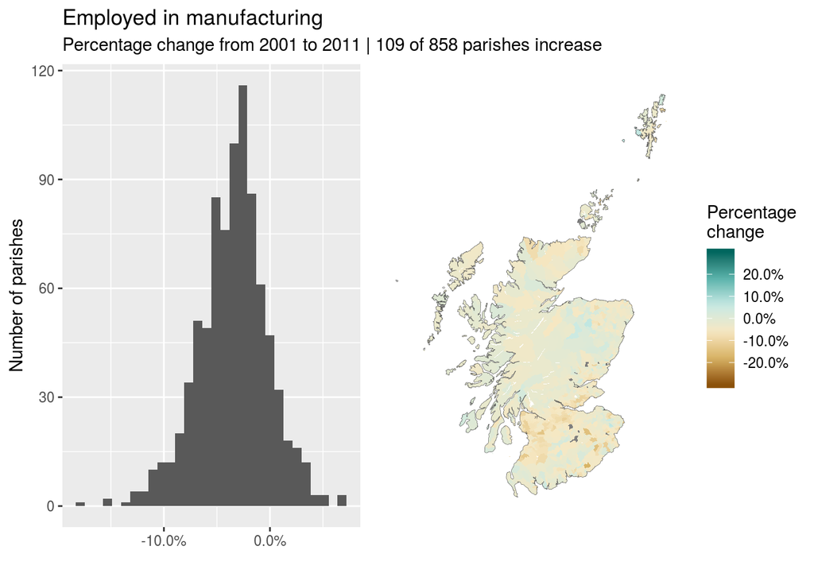

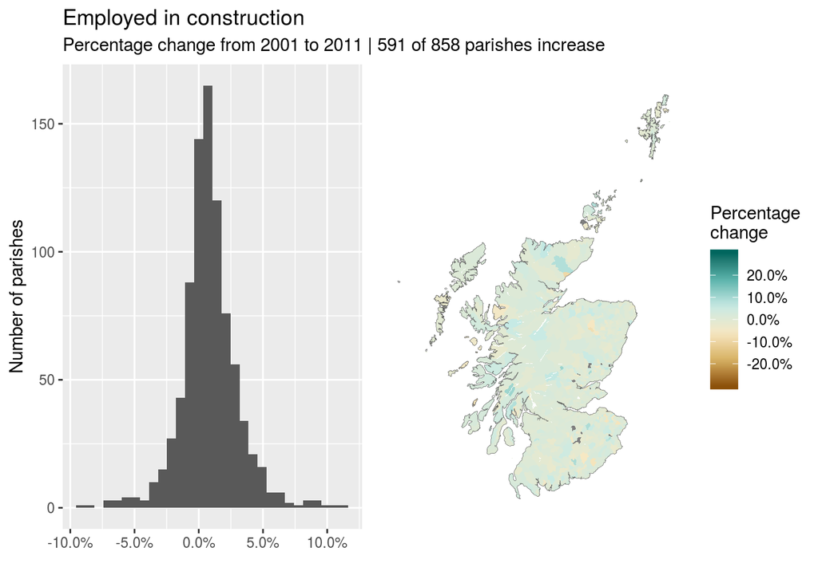

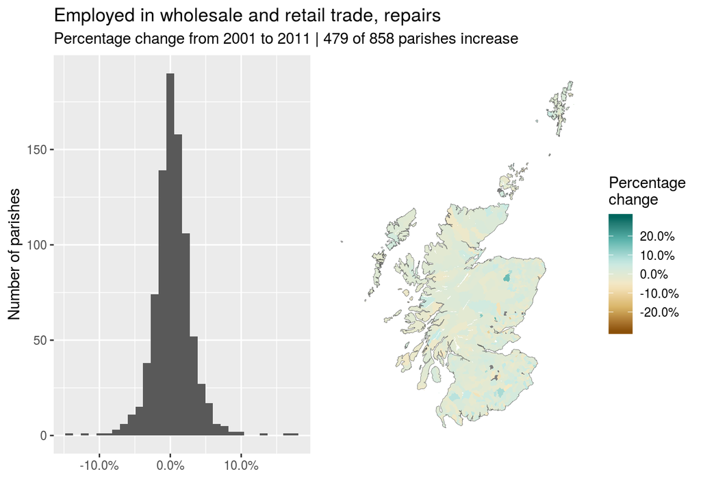

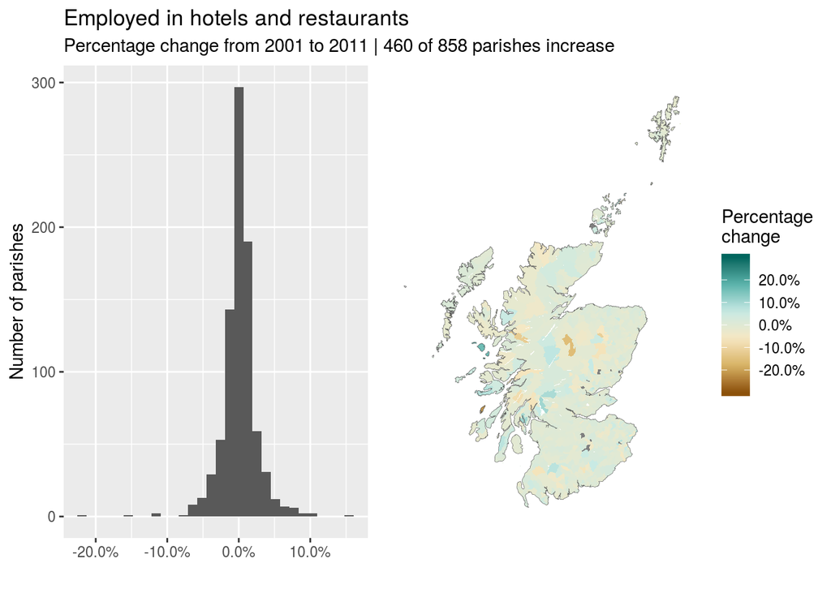

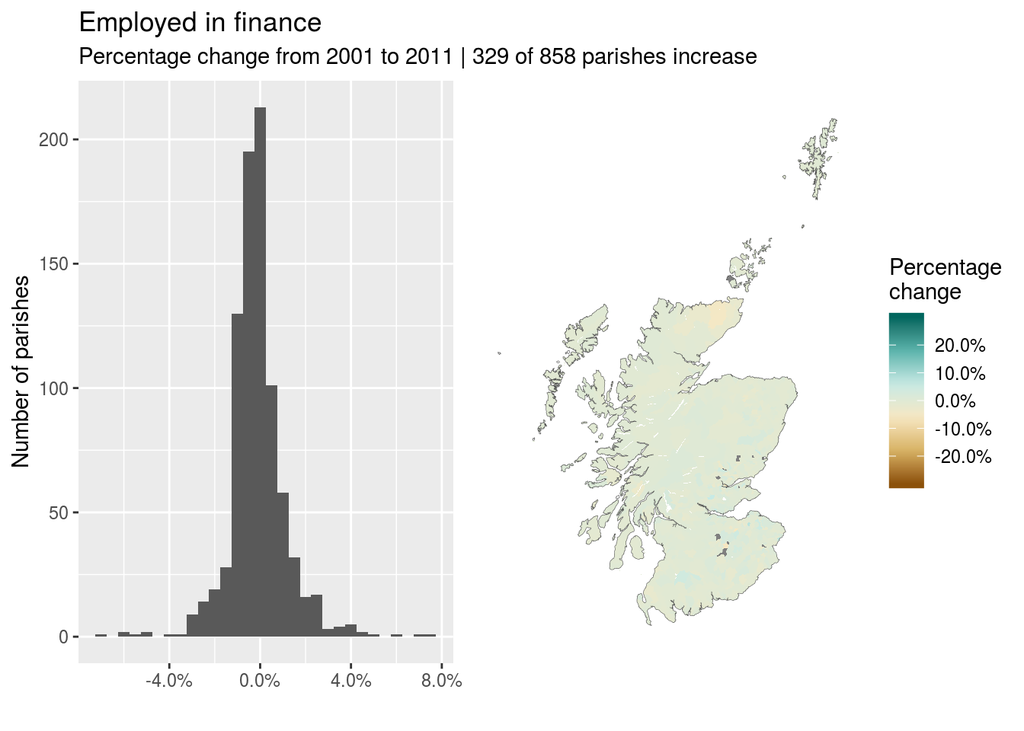

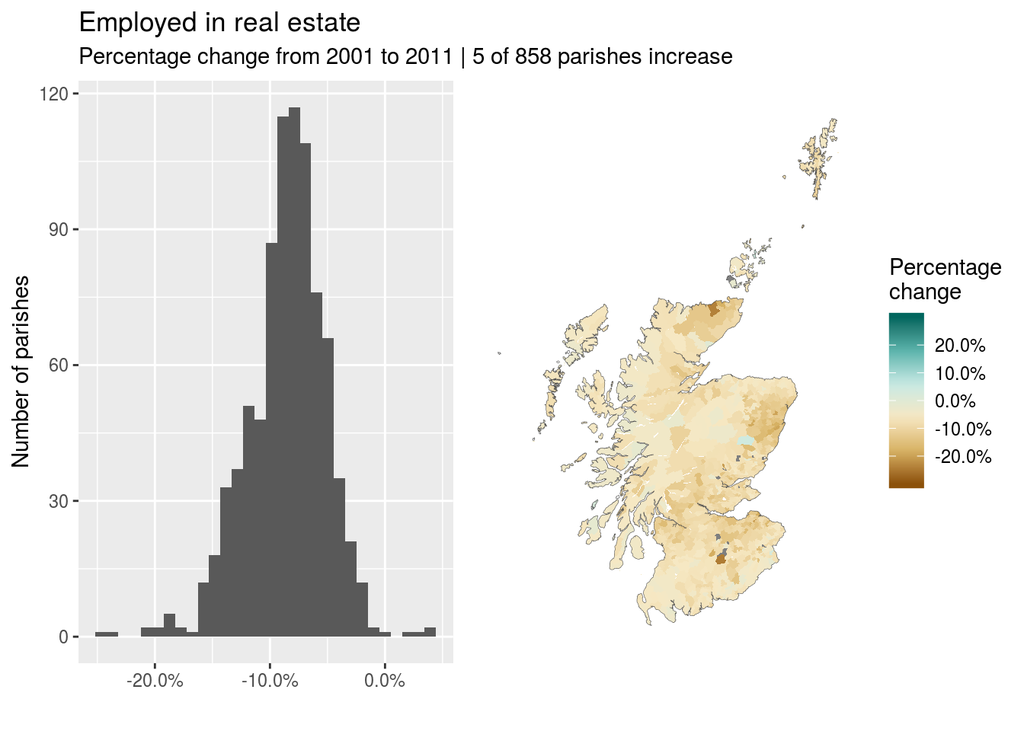

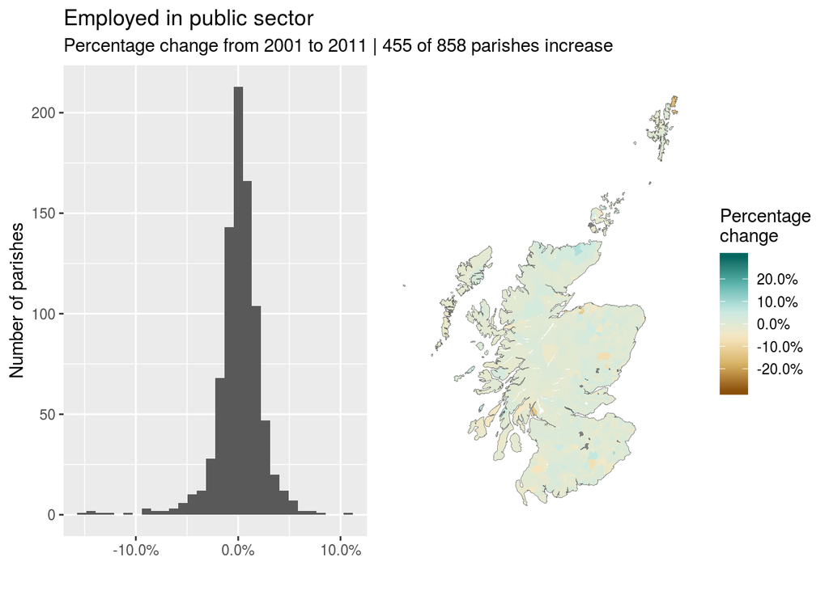

### Comparing agricultural and civic parishes

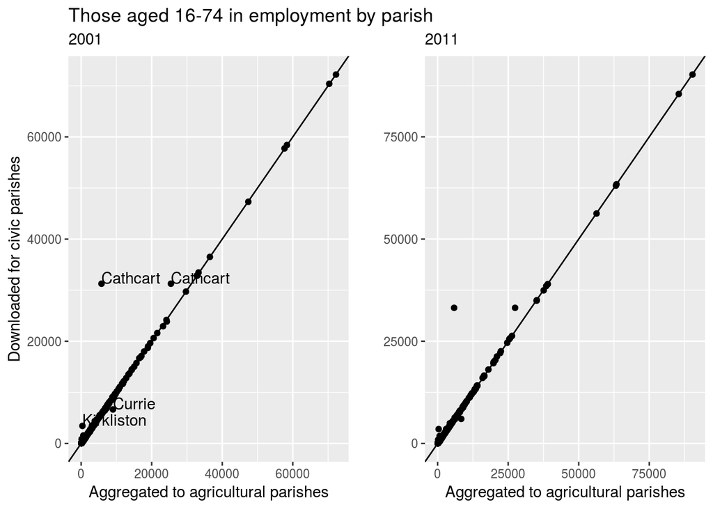

There are two agricultural parishes called Cathcart, when their populations are added together they sum to the population of the civic parish with the same name.

Total working population in 2011 for aggregated agricultural parishes is 2515940 people and for civic parishes 2516895 people. In 2001 the total working population for aggregated agricultural parishes is 2258453 people and for civic parishes 2261281 people.

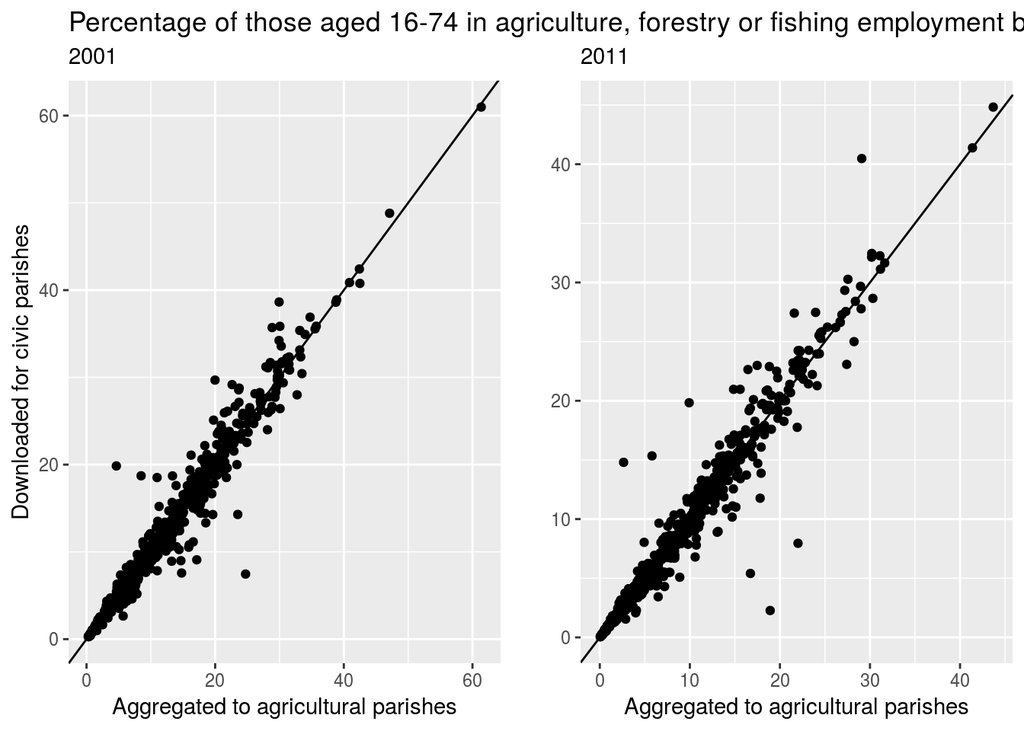